# DS as a Field - Week 3 Peer Graded Assignment

NYPD Shooting Incident Data Report

JF Schultz

2022-10-06

**Instructions:** Import, tidy and analyze the NYPD Shooting Incident dataset obtained. Be sure your project is reproducible and contains some visualization and analysis. You may use the data to do any analysis that is of interest to you. You should include at least two visualizations and one model. Be sure to identify any bias possible in the data and in your analysis.

### Overview

**Part One** - Import and Clean Data

**Part Two** - Exploratory Data Analysis

**Part Three** - Visual Analysis of Shooting Incidents by Borough

**Part Four** - Modeling and Statistical Analysis

**Part Five** - Criticisms and Bias

### Part One: Import and Clean Data

Data can be found here: https://catalog.data.gov/dataset

Dataset specific landing page: [NYPD Shooting Incident Data (Historic)](https://data.cityofnewyork.us/Public-Safety/NYPD-Shooting-Incident-Data-Historic-/833y-fsy8)

Summary of import and clean:

- Review data set for variable names/classes and look for bad values
- Remove variable(s) anticipated not needed: geospatial coordinates and location description
- Reclassify variable(s) as factors as needed
- Reclassify date variables as date class
- Remove/recode bad/missing values which should otherwise be NA

```r
url = 'https://data.cityofnewyork.us/api/views/833y-fsy8/rows.csv?accessType=DOWNLOAD'
df = read_csv(url, show_col_types = FALSE)
df <- df %>%
    select(-c(X_COORD_CD, Y_COORD_CD, Latitude, Longitude, Lon_Lat, LOCATION_DESC)) %>%
    mutate(across(BORO:VIC_RACE,  ~ as.factor(.))) %>%
    mutate(OCCUR_DATE = mdy(OCCUR_DATE)) %>%
    mutate_if(is.factor, ~ na_if(., 'U')) %>%
    mutate_if(is.factor, ~ na_if(., 'UNKNOWN'))
df$PERP_AGE_GROUP[df$PERP_AGE_GROUP %in% c('1020', '224', '940')] = NA
df = droplevels(df)
```

```r
head(df, n = 1)
```

| INCIDENT_KEY | OCCUR_DATE | OCCUR_TIME | BORO | PRECINCT | JURISDICTION_CODE | STATISTICAL_MURDER_FLAG | PERP_AGE_GROUP | PERP_SEX | PERP_RACE | VIC_AGE_GROUP | VIC_SEX | VIC_RACE |
| --- | --- | --- | --- | --- | --- | --- | --- | --- | --- | --- | --- | --- |
| 236168668 | 2021-11-11 | 15:04:00 | BROOKLYN | 79 | 0 | FALSE | NA | NA | NA | 18-24 | M | BLACK |

### Part Two: Some Exploratory Data Analysis

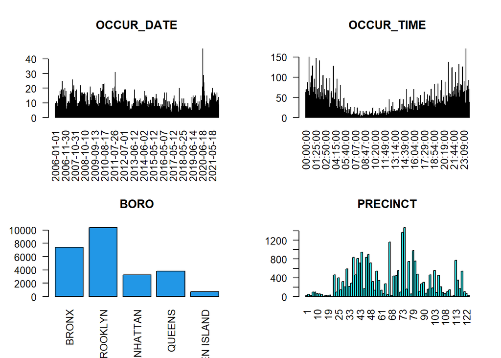

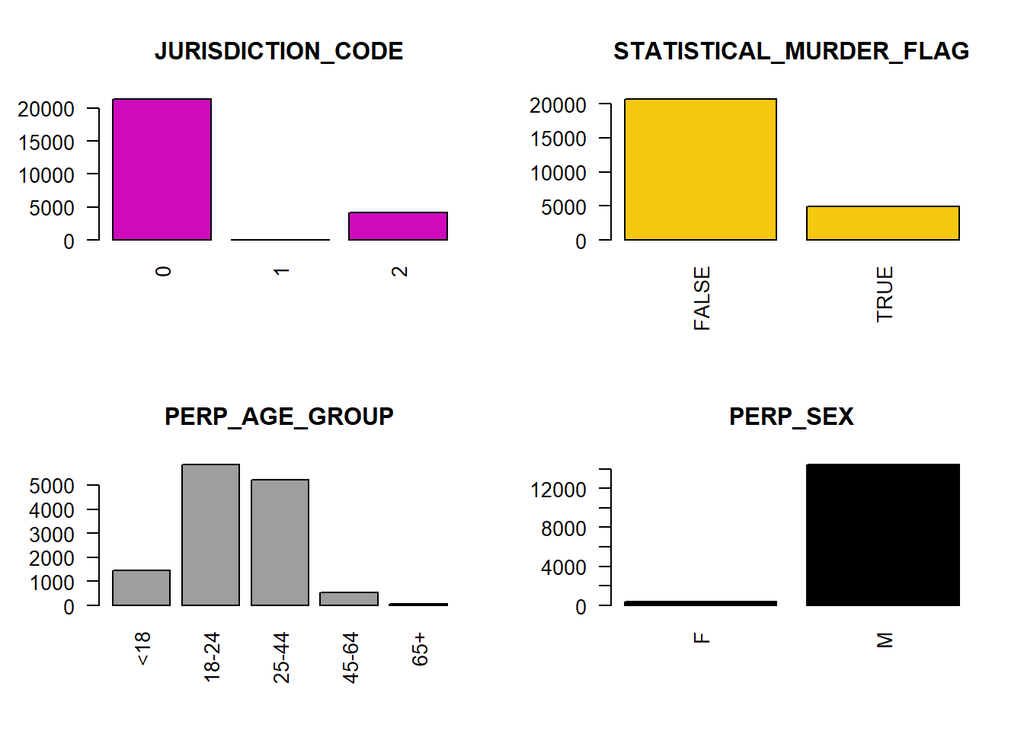

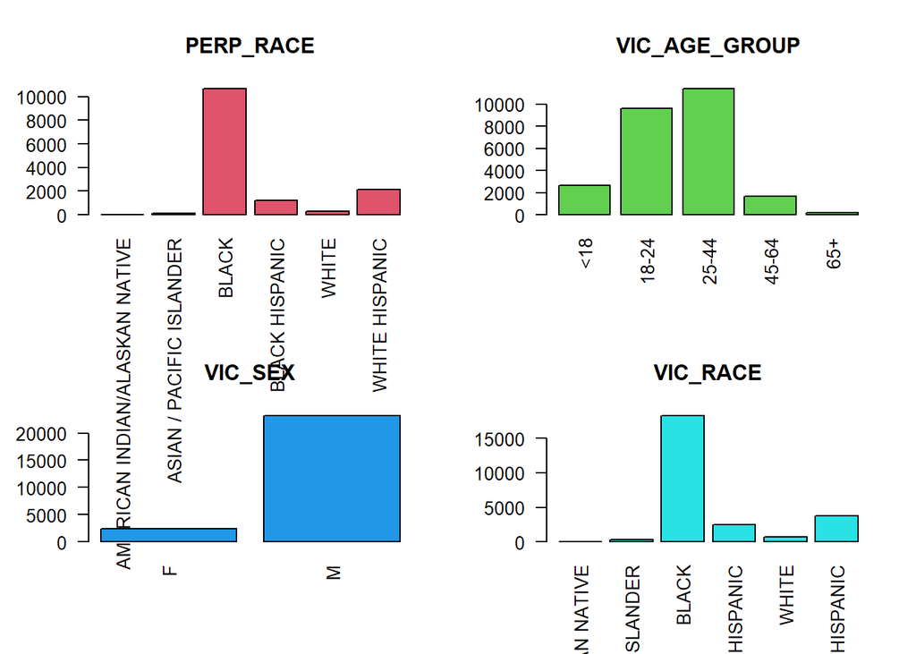

```r
par(mfrow = c(2,2))
for (i in 2:13){
      barplot(table(df[i]), col = i, las = 2, main = colnames(df)[i])
}
```

```r
par(mfrow = c(1,1))
```

### Part Three - Analysis of Incidents by Borough

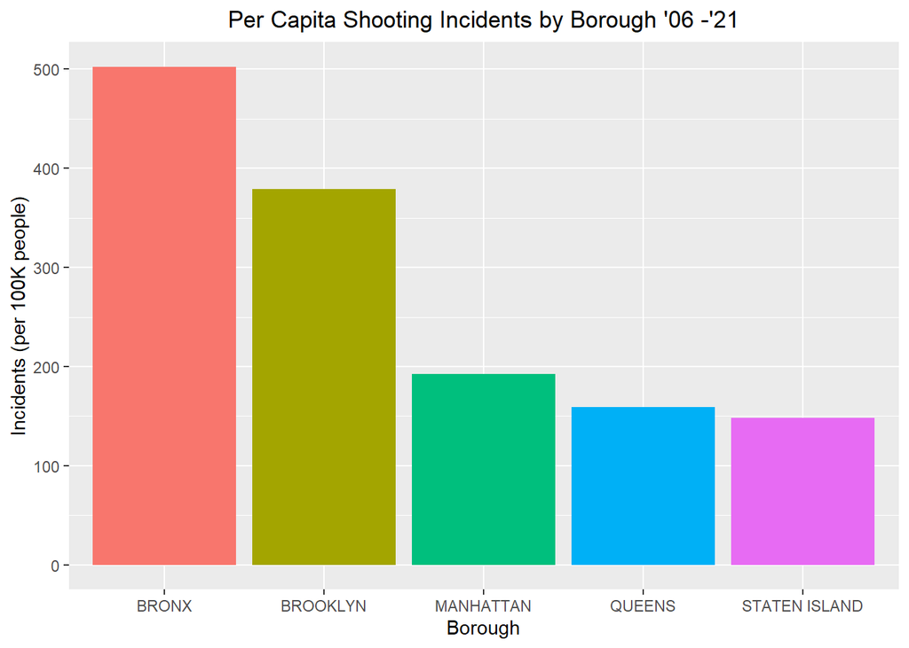

```r
df.pop = data.frame(BORO = levels(df$BORO),
                    pop = c(1472654, 2736074, 1694263, 2405464, 495747)) # from 2020 US Census Data
df %>%
  left_join(df.pop, by = 'BORO') %>%
  group_by(BORO) %>%
  mutate(per=n() / pop * 100000) %>%
  group_by(per, .add = TRUE) %>%
  summarise(n(), .groups = 'keep') %>%
  ggplot(aes(BORO, per)) +
      geom_col(aes(fill = BORO), show.legend = FALSE) +
      ggtitle('Per Capita Shooting Incidents by Borough \'06 -\'21') +
      ylab('Incidents (per 100K people)') +
      xlab('Borough') +
      theme(plot.title = element_text(hjust = 0.5))
```

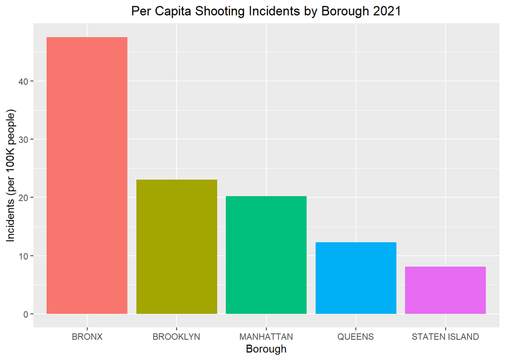

```r
df.pop = data.frame(BORO = levels(df$BORO),
                    pop = c(1472654, 2736074, 1694263, 2405464, 495747))
df %>%
  left_join(df.pop, by = 'BORO') %>%
  filter(year(OCCUR_DATE) == 2021) %>%
  group_by(BORO) %>%
  mutate(per=n() / pop * 100000) %>%
  group_by(per, .add = TRUE) %>%
  summarise(n(), .groups = 'keep') %>%
  ggplot(aes(BORO, per)) +
      geom_col(aes(fill = BORO), show.legend = FALSE) +
      ggtitle('Per Capita Shooting Incidents by Borough 2021') +
      ylab('Incidents (per 100K people)') +
      xlab('Borough') +
      theme(plot.title = element_text(hjust = 0.5))
```

#### Shooting Incidents by Borough, 2021 - Statistical Analysis

```r
df.observed21 <- df %>%
  left_join(df.pop, by = 'BORO') %>%
  filter(year(OCCUR_DATE) == 2021) %>%
  group_by(BORO) %>%
  mutate(per=n() / pop * 100000) %>%
  group_by(per, .add = TRUE) %>%
  summarise(n(), .groups = 'keep')
```

```r
chisq.test(x = df.observed21$per)
```

```
##
##  Chi-squared test for given probabilities
##
## data:  df.observed21$per
## X-squared = 42.566, df = 4, p-value = 1.273e-08
```

The Chi-squared test indicates that there is a statistically significant difference in the observed number of per shooting incidents per borough in comparision to an equal distribution across all boroughs.

#### Shooting Incidents per day by Borough, 2021

To further evaluate the difference in number of shooting incidents per borough, the number of shooting incidents per day by borough was examined further.

```r
df.byday21 <-df %>%
  filter(year(OCCUR_DATE) == 2021) %>%
  group_by(month(OCCUR_DATE), day(OCCUR_DATE), BORO) %>%
  summarise(count = n(), .groups = 'keep')
```

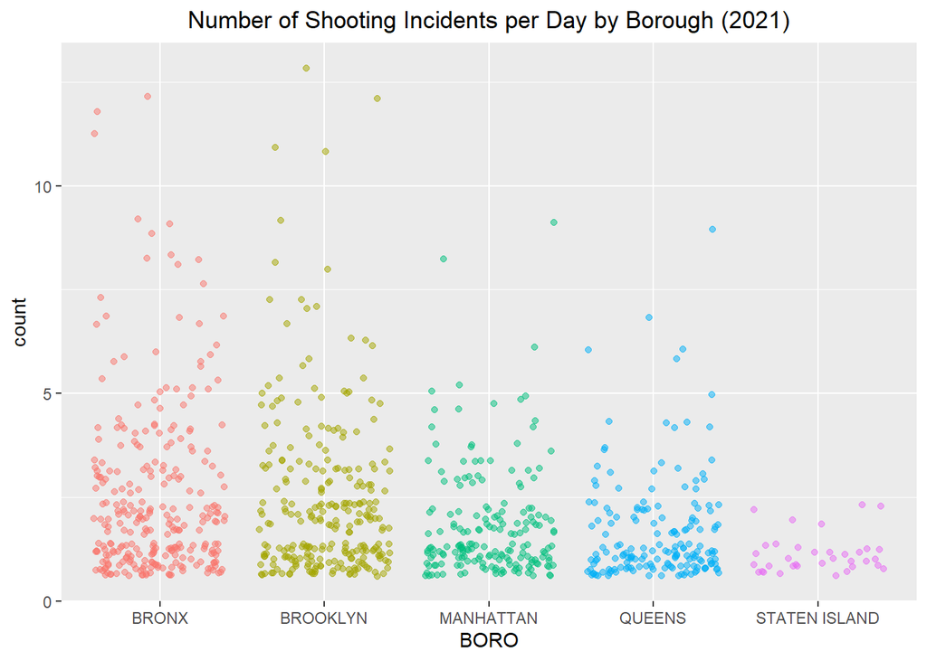

```r
ggplot(df.byday21, aes(y = count, x = BORO, color = BORO)) +
  geom_point(alpha = 0.5, position = 'jitter', show.legend = FALSE) +
  ggtitle('Number of Shooting Incidents per Day by Borough (2021)') +
  theme(plot.title = element_text(hjust = 0.5))
```

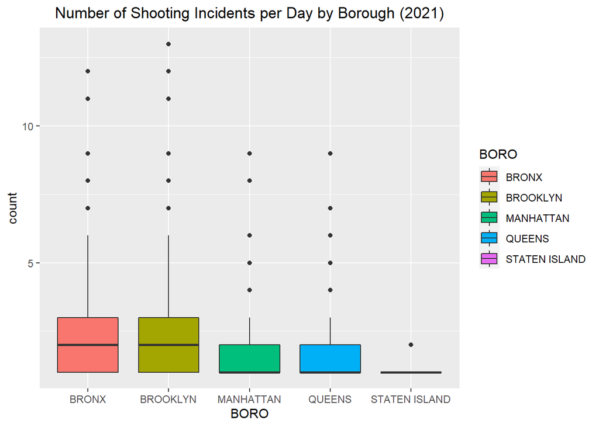

```r
ggplot(df.byday21, aes(y = count, x = BORO)) +
  geom_boxplot(aes(fill = BORO)) +
  ggtitle('Number of Shooting Incidents per Day by Borough (2021)') +
  theme(plot.title = element_text(hjust = 0.5))
```

### Part Four - Modeling and Statistical Analysis

A generalized linear model with poisson response for the number of shooting incidents per day predicted by the borough was constructed.

```r
glmodel = glm(data = df.byday21, count ~ BORO, family = poisson)
summary(glmodel)
```

```
##
## Call:
## glm(formula = count ~ BORO, family = poisson, data = df.byday21)
##
## Deviance Residuals:
##     Min       1Q   Median       3Q      Max
## -1.0974  -0.6813  -0.3464   0.2865   4.7338
##
## Coefficients:
##                   Estimate Std. Error z value Pr(>|z|)
## (Intercept)        0.92849    0.03777  24.583  < 2e-16 ***
## BOROBROOKLYN      -0.03801    0.05488  -0.693    0.488
## BOROMANHATTAN     -0.31651    0.06589  -4.803 1.56e-06 ***
## BOROQUEENS        -0.38563    0.06932  -5.563 2.65e-08 ***
## BOROSTATEN ISLAND -0.79496    0.16256  -4.890 1.01e-06 ***
## ---
## Signif. codes:  0 '***' 0.001 '**' 0.01 '*' 0.05 '.' 0.1 ' ' 1
##
## (Dispersion parameter for poisson family taken to be 1)
##
##     Null deviance: 1011.12  on 928  degrees of freedom
## Residual deviance:  939.82  on 924  degrees of freedom
## AIC: 3266.5
##
## Number of Fisher Scoring iterations: 5
```

```r
cat('p-value to reject the model: ', pchisq(glmodel$deviance, glmodel$df.residual, lower.tail = FALSE), '\n', '\n')
```

```
## p-value to reject the model:  0.3514486
##
```

Statistical testing of the residual deviance and degrees of freedom indicates that the model is valid.

Additionally, testing the analysis of variance also supports model validity.

```r
summary(aov(glmodel))
```

```
##              Df Sum Sq Mean Sq F value   Pr(>F)
## BORO          4  145.7   36.44   12.19 1.16e-09 ***
## Residuals   924 2762.1    2.99
## ---
## Signif. codes:  0 '***' 0.001 '**' 0.01 '*' 0.05 '.' 0.1 ' ' 1
```

The Analysis of Variance demonstrates that there is a statistical difference between the means of the groups. The Analysis of Variance does not indicate between which groups there is a statistical difference. Pairwise comparison is performed to test the differences between groups.

Pairwise comparison using Bonferroni method:

```r
emms = emmeans(glmodel, 'BORO')
pairs(emms, adjust = 'bonferroni')
```

```
##  contrast                  estimate     SE  df z.ratio p.value
##  BRONX - BROOKLYN            0.0380 0.0549 Inf   0.693  1.0000
##  BRONX - MANHATTAN           0.3165 0.0659 Inf   4.803  <.0001
##  BRONX - QUEENS              0.3856 0.0693 Inf   5.563  <.0001
##  BRONX - STATEN ISLAND       0.7950 0.1626 Inf   4.890  <.0001
##  BROOKLYN - MANHATTAN        0.2785 0.0671 Inf   4.151  0.0003
##  BROOKLYN - QUEENS           0.3476 0.0704 Inf   4.934  <.0001
##  BROOKLYN - STATEN ISLAND    0.7569 0.1630 Inf   4.642  <.0001
##  MANHATTAN - QUEENS          0.0691 0.0793 Inf   0.871  1.0000
##  MANHATTAN - STATEN ISLAND   0.4785 0.1671 Inf   2.864  0.0419
##  QUEENS - STATEN ISLAND      0.4093 0.1685 Inf   2.430  0.1510
##
## Results are given on the log (not the response) scale.
## P value adjustment: bonferroni method for 10 tests
```

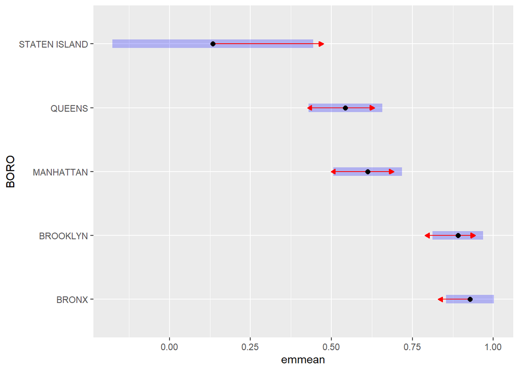

```r
plot(emms, comparisons = TRUE)
```

The plotted output provides an easy to understand interpretation of the pairwise comparisons:

### Part Five - Criticisms and Bias

Data Collection and Under-reporting

There are innumerable reasons why reported numbers are not as accurate as implied. The dataset is a collection of shooting incidents *reported to and recorded* by NYC Police Dept. There is the obvious discrepancy of shooting incidents not reported and hence not included in the report. Caution should be taken in interpreting the report the number of *actual* shooting incidents.

For example, the differences observed between boroughs is only a indication of the number of shooting incidents reported and recorded. That does not necessarily mean that boroughs with higher reported incidents had more. There could be failure to report for a number of reasons such as: shooting incident with no one injured and not reported, reluctance to go to the police to report the shooting, availability of police for reporting/investigating, public perception of local police to respond affecting reporting, fear of involvement with a police investigation, fear of retaliation for reporting a shooting. Some of these issues are readily quantifiable such as police budget, number of personnel, locale availability, hours of availability which all my affect reporting of acutal incidents. Other factors may be more difficult to quantify such as individual and community concerns and beliefs.

The dataset also provides an interesting glimpse into how bias and discrimination can be inherently built into the data collection and data set. For example, the mere act of collecting perpetrator race suggests that there is a suspected difference among race. For example that may be reflected in a disproportionate number of perpetrators or same-race/different-race incidents.

Caution should be taken in interpretation of the information and future recommendations. Such simple results as the number of shooting incidents by borough can be interpreted and form the basis of recommendations in different ways. Increased police presence and staffing in areas of higher incidence doesn’t necessarily address the underlying reasons for increased numbers of incidents or will necessarily reduce the number of incidents. Areas with high incidence may already have higher ratios of per capita police staffing and budgets.

These criticisms highlight some of the difficulties in making subjective conclusions, decisions, and recommendations from seemingly objective data which may be troubled with underlying bias, incompleteness, or inability to capture the complexity of the real world.